# Practical Machine Learning: Prediction Assignment

#### In this project, we use data from accelerometers on the belt, forearm, arm, and dumbell of 6 participants, who were asked to perform barbell lifts correctly and incorrectly in 5 different ways. For more information, please visit: http://groupware.les.inf.puc-rio.br/har.

### Getting and Cleaning the Data

The training data for this project are available here: https://d396qusza40orc.cloudfront.net/predmachlearn/pml-training.csv

The test data are available here: https://d396qusza40orc.cloudfront.net/predmachlearn/pml-testing.csv

We load the training and testing data sets directly from their source and assign “NA” value to missing values:

```r
trainInt <- "http://d396qusza40orc.cloudfront.net/predmachlearn/pml-training.csv"
testInt <- "http://d396qusza40orc.cloudfront.net/predmachlearn/pml-testing.csv"
train <- read.csv(url(trainInt), na.strings=c("NA",""))
test <- read.csv(url(testInt), na.strings=c("NA",""))
```

We assume that variables with a lot of missing observations will not be very usefull for the analysis. Therefore, we remove all variables that contain “NA” values.

```r
test  <- test[ , colSums(is.na(train)) == 0]
train <- train[ , colSums(is.na(train)) == 0]
```

We also remove variables that should be irrelevant, i.e. observation label, user info, time/date and undefined. These correspond to the first seven features.

```r
train <- train[,-c(1:7)]
test <- test[,-c(1:7)]
```

```r
library(lattice)
library(ggplot2)
library(caret)
set.seed(1)
forTrain <- createDataPartition(y=train$classe, p=0.7, list=FALSE)
train <- train[forTrain,]
crossValidation <- train[-forTrain,]
```

### Random-forest classification model

We now built a prediction model to solve our classification problem. In particular, we shall use random forest with 100 trees.

```r
library(randomForest)
model <- randomForest(classe ~ ., data=train, ntree=100, importance=TRUE)
```

### Variable importance

We can see wich variables are more important for the creation of the model, using the “varImpPlot” function.

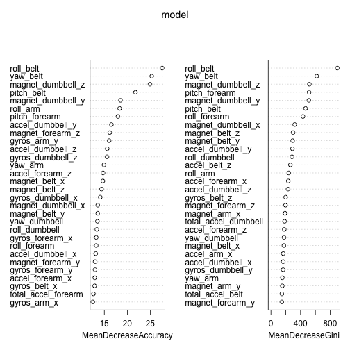

```r
varImpPlot(model)
```

### Cross Validation

```r
pred <- predict(model, crossValidation)
confus <- confusionMatrix(crossValidation$classe, pred)
accuracy <- confus$overall[1]
accuracy
```

```
## Accuracy
##        1
```

```r
outOfSample <- 1 - accuracy
as.numeric(outOfSample)
```

```
## [1] 0
```

### Conclusion

```r
predTest <- predict(model, test)
predTest
```

```
##  1  2  3  4  5  6  7  8  9 10 11 12 13 14 15 16 17 18 19 20
##  B  A  B  A  A  E  D  B  A  A  B  C  B  A  E  E  A  B  B  B
## Levels: A B C D E
```